# F9_16_PF_AIPANRIRNDFP

Net Rntl Incm Re Not Debt Fincd Prop - Business code · Amount report

## Overview

**Description**

Net Rntl Incm Re Not Debt Fincd Prop - Business code

**Table**

`PF-P16-T00-INCOME-PRODUCING-ACTS` (one)

**Location code**

`F990-PF-PART-16-A-LINE-05B-COL-A`, `F990-PF-PART-16-A-LINE-05B-COL-D`, `F990-PF-PART-16-A-LINE-05B-COL-C`, `F990-PF-PART-16-A-LINE-05B-COL-E`, `F990-PF-PART-16-A-LINE-05B-COL-B`

**Family**

`F990-PF-PART-16-A-LINE-05B-COL-A`

**Data type**

**Scope**

PF

**Status**

unreviewed

10

xpaths mapped (5 observed)

19,207

filings with a value

2023–2023

tax years observed

7

open flags (1 errors)

## Flags

| Severity | Flag | Xpath | Detail |
| --- | --- | --- | --- |
| ⚠ error | `COLLISION` | IRS990PF/AnalysisIncomeProducingActyGrp/NetRntlIncmReNotDebtFincdProp/ExclusionAmt | 6853 filings contain 2+ of its xpaths; most common set: /Return/ReturnData/IRS990PF/AnalysisIncomeProducingActyGrp/NetRntlIncmReNotDebtFincdProp/ExclusionAmt ; /Return/ReturnData/IRS990PF/AnalysisInco… |
| ▲ warn | `SCALE_BREAK` | IRS990PF/AnalysisIncomeProducingActyGrp/NetRntlIncmReNotDebtFincdProp/BusinessCd | 990PF medians differ 33195x across xpaths (BusinessCd vs ExclusionCd) |
| ⓘ info | `UNOBSERVED` | IRS990PF/AnalysisIncomeProducingActy/NetRntlIncmReNotDebtFincdProp/BusinessCode | never observed in TY2009-2024 filings |
| ⓘ info | `UNOBSERVED` | IRS990PF/AnalysisIncomeProducingActy/NetRntlIncmReNotDebtFincdProp/ExclusionAmount | never observed in TY2009-2024 filings |
| ⓘ info | `UNOBSERVED` | IRS990PF/AnalysisIncomeProducingActy/NetRntlIncmReNotDebtFincdProp/ExclusionCode | never observed in TY2009-2024 filings |
| ⓘ info | `UNOBSERVED` | IRS990PF/AnalysisIncomeProducingActy/NetRntlIncmReNotDebtFincdProp/RelatedOrExemptFunctionIncome | never observed in TY2009-2024 filings |
| ⓘ info | `UNOBSERVED` | IRS990PF/AnalysisIncomeProducingActy/NetRntlIncmReNotDebtFincdProp/UnrelatedBusinessIncomeAmount | never observed in TY2009-2024 filings |

## Xpaths

All mapped xpaths (under /Return/ReturnData or /Return/ReturnHeader), oldest first. Charts label each series by its xpath.

| Xpath | Form | Chart label | First year | Last year | Versions | Filings | Repeats in |
| --- | --- | --- | --- | --- | --- | --- | --- |
| IRS990PF/AnalysisIncomeProducingActyGrp/NetRntlIncmReNotDebtFincdProp/ExclusionAmt | IRS990PF | …oducingActyGrp/NetRntlIncmReNotDebtFincdProp/ExclusionAmt | 2023 | 2023 | 4 | 6,684 | 0.0% |
| IRS990PF/AnalysisIncomeProducingActyGrp/NetRntlIncmReNotDebtFincdProp/RelatedOrExemptFunctionIncmAmt | IRS990PF | …RntlIncmReNotDebtFincdProp/RelatedOrExemptFunctionIncmAmt | 2023 | 2023 | 4 | 5,270 | 0.0% |
| IRS990PF/AnalysisIncomeProducingActyGrp/NetRntlIncmReNotDebtFincdProp/UnrelatedBusinessTaxblIncmAmt | IRS990PF | …tRntlIncmReNotDebtFincdProp/UnrelatedBusinessTaxblIncmAmt | 2023 | 2023 | 4 | 5,191 | 0.0% |
| IRS990PF/AnalysisIncomeProducingActyGrp/NetRntlIncmReNotDebtFincdProp/ExclusionCd | IRS990PF | …roducingActyGrp/NetRntlIncmReNotDebtFincdProp/ExclusionCd | 2023 | 2023 | 4 | 1,812 | 0.0% |
| IRS990PF/AnalysisIncomeProducingActyGrp/NetRntlIncmReNotDebtFincdProp/BusinessCd | IRS990PF | …ProducingActyGrp/NetRntlIncmReNotDebtFincdProp/BusinessCd | 2023 | 2023 | 4 | 250 | 0.0% |
| IRS990PF/AnalysisIncomeProducingActy/NetRntlIncmReNotDebtFincdProp/BusinessCode | IRS990PF | …eProducingActy/NetRntlIncmReNotDebtFincdProp/BusinessCode |  |  |  | 0 |  |
| IRS990PF/AnalysisIncomeProducingActy/NetRntlIncmReNotDebtFincdProp/ExclusionAmount | IRS990PF | …oducingActy/NetRntlIncmReNotDebtFincdProp/ExclusionAmount |  |  |  | 0 |  |
| IRS990PF/AnalysisIncomeProducingActy/NetRntlIncmReNotDebtFincdProp/ExclusionCode | IRS990PF | Other |  |  |  | 0 |  |
| IRS990PF/AnalysisIncomeProducingActy/NetRntlIncmReNotDebtFincdProp/RelatedOrExemptFunctionIncome | IRS990PF | Other |  |  |  | 0 |  |
| IRS990PF/AnalysisIncomeProducingActy/NetRntlIncmReNotDebtFincdProp/UnrelatedBusinessIncomeAmount | IRS990PF | Other |  |  |  | 0 |  |

## Coverage

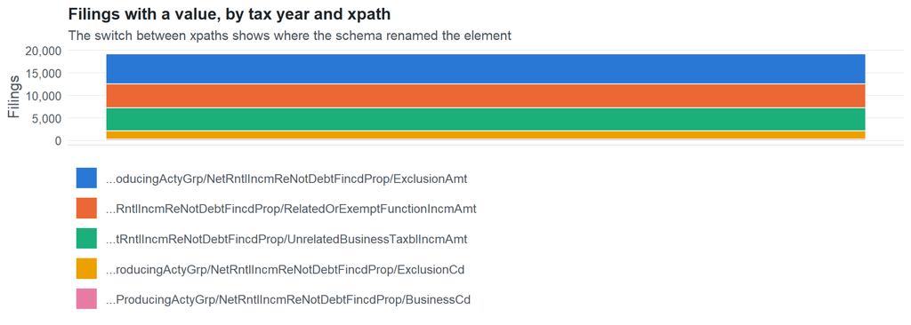

**Table view**

Table view: filings by tax year and series

| Tax year | …oducingActyGrp/NetRntlIncmReNotDebtFincdProp/ExclusionAmt | …RntlIncmReNotDebtFincdProp/RelatedOrExemptFunctionIncmAmt | …tRntlIncmReNotDebtFincdProp/UnrelatedBusinessTaxblIncmAmt | …roducingActyGrp/NetRntlIncmReNotDebtFincdProp/ExclusionCd | …ProducingActyGrp/NetRntlIncmReNotDebtFincdProp/BusinessCd |
| --- | --- | --- | --- | --- | --- |
| 2023 | 6,684 | 5,270 | 5,191 | 1,812 | 250 |

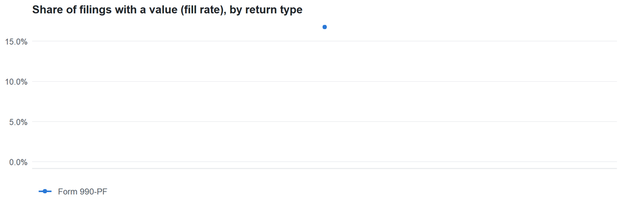

**Table view**

Table view: fill rate

| Tax year | Return type | Filings | All filings | Fill rate |
| --- | --- | --- | --- | --- |
| 2023 | Form 990-PF | 19,207 | 114,558 | 16.77% |

## Values

| Result | Check | Detail |
| --- | --- | --- |
| ✓ pass | Values parse as numbers | 100.0% of values are numeric |
| ⚠ fail | Pooled xpaths are on the same scale (same return type) | medians differ 33195.0x (990PF: …ProducingActyGrp/NetRntlIncmReNotDebtFincdProp/BusinessCd vs …roducingActyGrp/NetRntlIncmReNotDebtFincdProp/ExclusionCd) |
| ⓘ info | Sign convention | 2.3% of values are negative (fine for net amounts) |

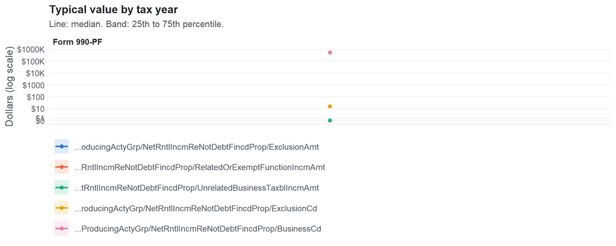

**Table view**

Table view: quartiles by tax year

[output not shown]

Summary by xpath and return type (all years)

| Series | Return | Filings | % numeric | % zero | % negative | Median (typical year) | P99 (typical year) |
| --- | --- | --- | --- | --- | --- | --- | --- |
| …oducingActyGrp/NetRntlIncmReNotDebtFincdProp/ExclusionAmt | 990PF | 6,684 | 100 | 74.4 | 4.5 | 0 | 487674 |
| …RntlIncmReNotDebtFincdProp/RelatedOrExemptFunctionIncmAmt | 990PF | 5,270 | 100 | 94.1 | 1.3 | 0 | 123746 |
| …tRntlIncmReNotDebtFincdProp/UnrelatedBusinessTaxblIncmAmt | 990PF | 5,191 | 100 | 95.9 | 1.4 | 0 | 27942 |
| …roducingActyGrp/NetRntlIncmReNotDebtFincdProp/ExclusionCd | 990PF | 1,812 | 100 | 0 | 0 | 16 | 26 |
| …ProducingActyGrp/NetRntlIncmReNotDebtFincdProp/BusinessCd | 990PF | 250 | 100 | 0.4 | 0 | 531120 | 716049 |

## Examples

| Tax year | Return | Xpath | Organization | Value | Source |
| --- | --- | --- | --- | --- | --- |
| 2023 | 990PF | IRS990PF/AnalysisIncomeProducingActyGrp/NetRntlIncmReNotDebtFincdProp/BusinessCd | THE WI & INEZ DAVIS FOUNDATION | 531120 | [XML](https://gt990datalake-rawdata.s3.amazonaws.com/EfileData/XmlFiles/202413199349104011_public.xml) |
| 2023 | 990PF | IRS990PF/AnalysisIncomeProducingActyGrp/NetRntlIncmReNotDebtFincdProp/ExclusionAmt | MERLIN & JO ANN FJARLI FOUNDATION INC | 436273 | [XML](https://gt990datalake-rawdata.s3.amazonaws.com/EfileData/XmlFiles/202423219349100617_public.xml) |
| 2023 | 990PF | IRS990PF/AnalysisIncomeProducingActyGrp/NetRntlIncmReNotDebtFincdProp/ExclusionCd | MERLIN & JO ANN FJARLI FOUNDATION INC | 16 | [XML](https://gt990datalake-rawdata.s3.amazonaws.com/EfileData/XmlFiles/202423219349100617_public.xml) |
| 2023 | 990PF | IRS990PF/AnalysisIncomeProducingActyGrp/NetRntlIncmReNotDebtFincdProp/RelatedOrExemptFunctionIncmAmt | BE THE VILLAGE | 0 | [XML](https://gt990datalake-rawdata.s3.amazonaws.com/EfileData/XmlFiles/202433209349105853_public.xml) |
| 2023 | 990PF | IRS990PF/AnalysisIncomeProducingActyGrp/NetRntlIncmReNotDebtFincdProp/UnrelatedBusinessTaxblIncmAmt | J & S FAMILY FOUNDATION | 1206 | [XML](https://gt990datalake-rawdata.s3.amazonaws.com/EfileData/XmlFiles/202413189349104016_public.xml) |

## Reviewer checklist

- The definition matches the form line and instructions for every xpath’s schema years.
- Every xpath pooled here measures the same thing on the 990 and 990-EZ (close enough for analysis).
- The coverage chart has no unexplained gaps or jumps between tax years.
- Each open flag is fixed, or accepted with a note in validation_log.csv.
- Values are whole dollars, not thousands, and not a percentage.
- Current year / prior year and beginning / end of year match the variable name (CY, PY, BOY, EOY).
- Negative values are expected only for net amounts (gains, net income, fund balances).
- The 990 and 990-EZ medians differ only as much as the filer populations do.

Record the review as a row in `inst/extdata/src/validation_log.csv` (variable_name, reviewer, date, status, note). Evidence built (unknown) from the ef2 DuckDB builds (tax years 2023).